# Gpdp Via Mdptoolbox Cont

```r
#knitr::opts_chunk$set(eval=FALSE)
#devtools::install_github("cboettig/gpmanagement@b3b765cbceb51c9b0b8cb2724e395353ec365df9")
library("MDPtoolbox")
library("gpmanagement")
library("tidyr")
library("dplyr")
```

```r
library("ggplot2")
```

### True model

```r
p <- c(2, 100, 50)
f <- function (x, h){
  sapply(x, function(x) {
    x <- pmax(0, x - h)
    x * exp(p[1] * (1 - x/p[2]) * (x - p[3])/p[2])
  })
}

sigma_g <- 0.1
pdfn <- function(x, mu, sigma = sigma_g){
  dlnorm(x, log(mu), sdlog = sigma)
}

z_g <- function() rlnorm(1, 0, sigma_g)
```

```r
  set.seed(0)
  Tobs <- 40


  x <- numeric(Tobs)
  x[1] <- 60
  for(t in 1:(Tobs-1))
    x[t+1] = z_g() * f(x[t], h=0)
  obs <- data.frame(x = c(0,
                          pmax(rep(0,Tobs-1), x[1:(Tobs-1)])),
                    y = c(0,
                          x[2:Tobs]))
  xObs <- obs$x
  yObs <- obs$y
  xPred <- seq(0, 1.1 * max(xObs), length = 50)
```

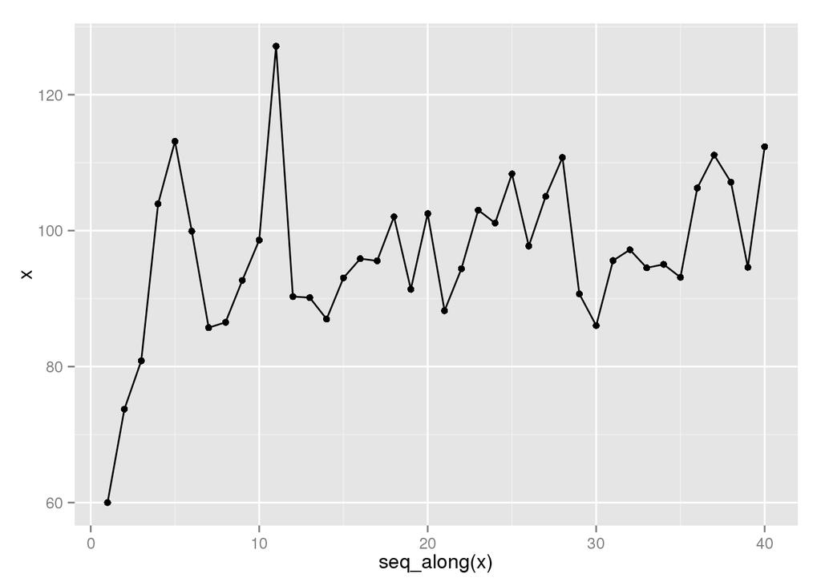

```r
qplot(seq_along(x), x) + geom_line()
```

Now the GP estimation from NIMBLE. Let’s emphasize shorter length-scales with the prior to compare:

```r
# having this work with output from `nimbleCode` might be more natural than `expression`
priors <- expression({
  rho ~ dgamma(1, 1)
  sigGP ~ dunif(0, 1e5)
  sigOE ~ dunif(0, 1e5)
})
```

```r
fit <- gp_setup(xObs, yObs, xPred)
```

```
## [1] RW_block sampler: rho, sigGP, sigOE,  adaptive: TRUE,  adaptScaleOnly: FALSE,  adaptInterval: 200,  scale: 1,  propCov: identity
```

```r
Cmcmc <- fit$Cmcmc
Cpred <- fit$Cpred
Cmodel <- fit$Cmodel
```

```r
system.time(Cmcmc$run(100000))
```

```
##    user  system elapsed
##  17.392   0.012  17.395
```

```r
  samples <- as.matrix(Cmcmc$mvSamples)
  ## basic sanity check
  testthat::expect_identical(Cmodel$getNodeNames(topOnly = TRUE), colnames(samples))
```

predict from GP model using posterior MCMC samples

```r
system.time(Cpred$run(samples))
```

```
##    user  system elapsed
##  22.816   0.008  22.811
```

Posteriors

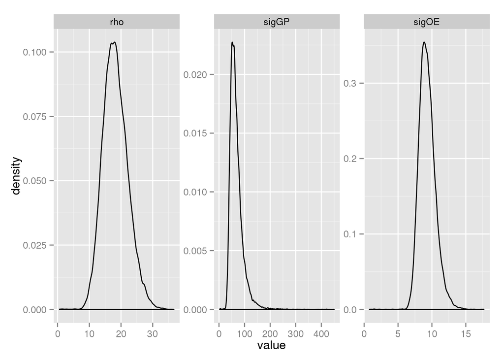

```r
samples <- as.data.frame(as.matrix(Cmcmc$mvSamples))
df <- tidyr::gather(samples)
ggplot(df) +
  geom_density(aes(value)) +
  facet_wrap(~key, scale='free')
```

extract predictions: E and C

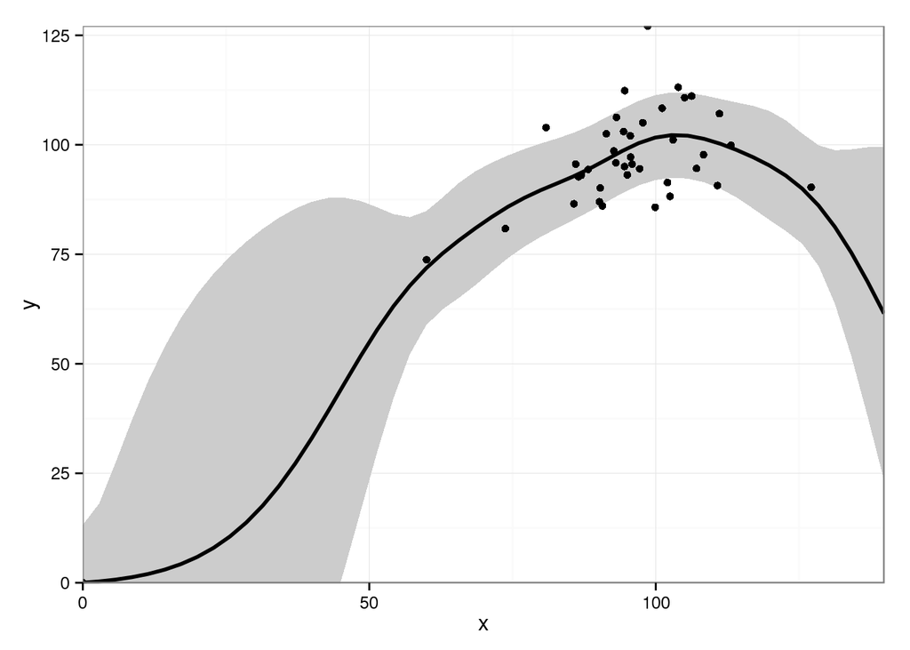

```r
  E <- Cpred$getE()
  C <- Cpred$getC()

obs <- data.frame(x = xObs, y = yObs)
pred <- data.frame(x = xPred, y = E, ymin = E - sqrt(diag(C)), ymax = E + sqrt(diag(C)))
ggplot2::ggplot(pred) +
  geom_ribbon(aes(x = x,y = y, ymin = ymin, ymax = ymax), fill = "grey80") +
  geom_line(aes(x = x, y = y), size=1) +
  geom_point(data = obs, aes(x,y)) +
  coord_cartesian(xlim = range(c(xObs, xPred)), ylim = range(c(yObs,E))) +
  theme_bw()
```

## Decision theory

```r
states <- xPred # Vector of all possible states
actions <- states # Vector of actions: harvest
```

Let’s consider a slight variation of the most trivial utility function: one which explicitly adds a cost to completely exhausting the stock (or reducing the stock by more than, say 95% in this case.) This should be somewhat similar to the impact of no discount rate.

```r
# Utility function
discount = 0.99

#get_utility <- function(x,h) pmin(x,h)
#R <- outer(states, actions, get_utility)

R <- sapply(actions, function(h){
      sapply(states, function(x){
  if(h < x)
    h
  else
     - 1 * max(states)
  })
})
```

Implementing policy

```r
z <- function() rlnorm(1, meanlog = 0, sdlog = sigma_g)

simulate_policy <- function(states, actions, policy, f, z, s0, steps = 50, utility = function(s,a) NA, discount = 1){
  s <- numeric(steps)
  a <- numeric(steps)
  u <- numeric(steps)
  s[1] <- s0
  for(t in 1:(steps-1)){

    a[t] <- actions[policy[which.min(abs(states - s[t]))]]
    s[t+1] <- z() * f(s[t], a[t])
    u[t] <- utility(s[t], a[t]) * discount ^ t
  }

  # Final action determined but not implemented
  a[steps] <- actions[policy[which.min(abs(states - s[t]))]]

  data.frame(time = 1:steps, state = s, action = a, utility = u)
}
```

### GP model

```r
gp_matrix <- function(states, actions, E, C){

  transition <- array(0, dim = c(length(states), length(states), length(actions)))
  K <- length(states)
  sigmas <- sqrt(diag(C))

  for (k in 1:length(states)) {
    for (i in 1:length(actions)) {
      nextpop <- E[k] - actions[i]
      if(nextpop <= 0) {
        transition[k, , i] <- c(1, rep(0, K - 1))
      } else {
        transition[k, , i] <- dnorm(states, nextpop, sigmas[i]) / sum(dnorm(states, nextpop, sigmas[i]))
      }
    }
  }
  transition
}

P_gp <- gp_matrix(states, actions, E, C)
```

```r
mdp_check(P = P_gp, R = R)
```

```
## [1] ""
```

```r
gp <- mdp_value_iteration(P_gp, R, discount = discount, epsilon = 0.00001, max_iter = 5e3, V0 = numeric(length(states)))
```

```
## [1] "MDP Toolbox: iterations stopped, epsilon-optimal policy found"
```

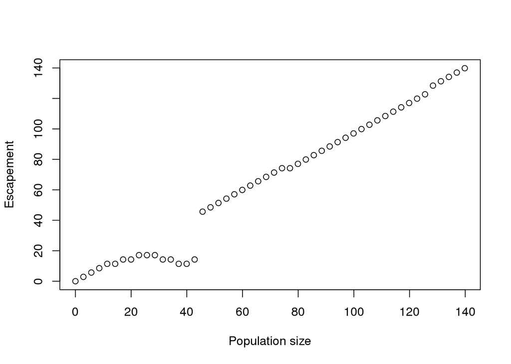

```r
plot(states, states - actions[gp$policy],  xlab="Population size", ylab="Escapement")
```

```r
data.frame(reps = 1:50) %>%
  group_by(reps) %>%
  do(simulate_policy(states,actions, gp$policy, f, z, s0 = 100, steps = 20, utility = pmin, discount = discount)[c("time", "state", "utility")]) ->
  sims

mean(sims$utility)
```

```
## [1] 2.421142
```

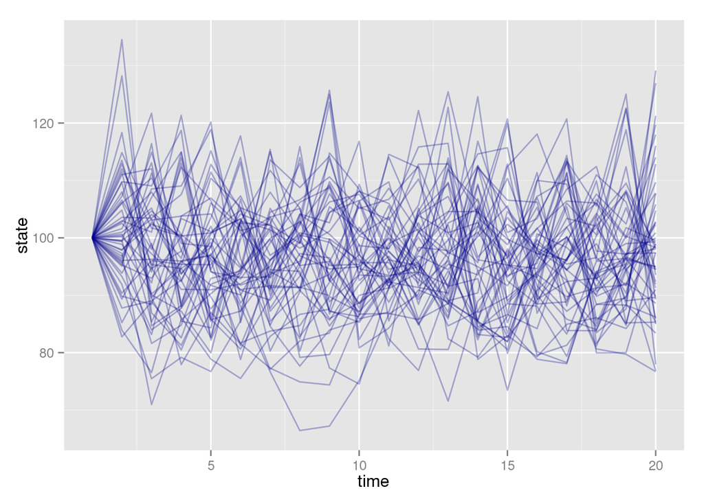

```r
ggplot(sims) + geom_line(aes(time, state, group = reps), alpha = 0.3, col = "darkblue")
```

With this amount of data, the gp solution is too cautious, and avoids any exploitation.

#### Simulate under the true model

```r
data.frame(reps = 1:50) %>%
  group_by(reps) %>%
  do(simulate_policy(states, actions, gp$policy, f, z, s0 = 100, steps = 20, utility = pmin, discount = discount)[c("time", "state", "utility")]) ->
  sims

mean(sims$utility)
```

```
## [1] 2.394725
```

(Average utility is approximate here since it does not include penalty; since a function and not a matrix is requred by this function at this time.)

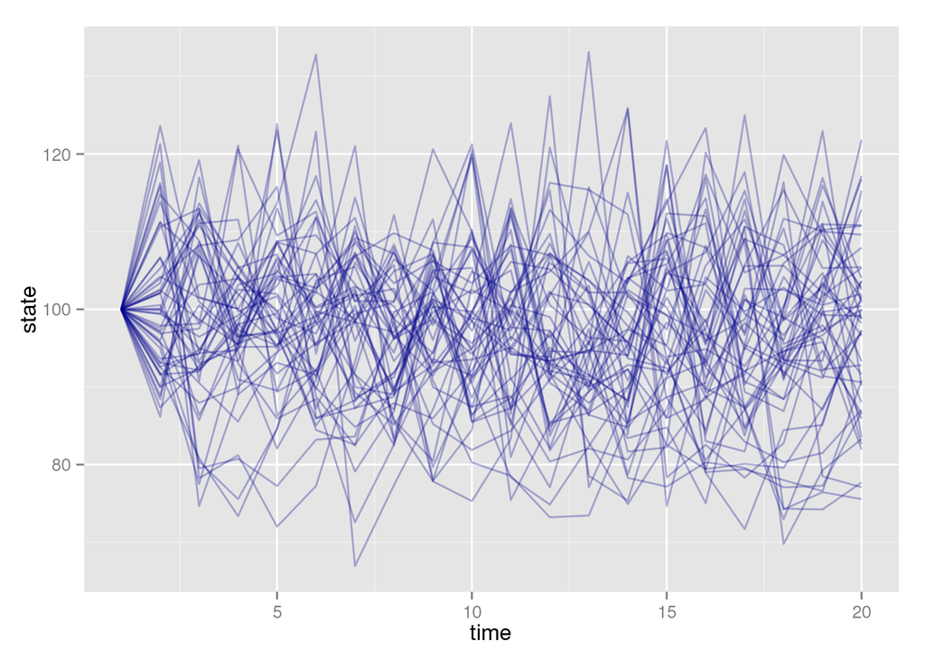

```r
ggplot(sims) + geom_line(aes(time, state, group = reps), alpha = 0.3, col = "darkblue")
```

```r
P <- transition_matrix(states, actions, f, pdfn)
#get_utility <- function(x,h) pmin(x,h)
#R <- outer(states, actions, get_utility)
```

```r
mdp_check(P = P, R = R)
```

```
## [1] ""
```

```r
mdp <- mdp_value_iteration(P, R, discount = discount, epsilon = 0.001, max_iter = 5e3, V0 = numeric(length(states)))
```

```
## [1] "MDP Toolbox: iterations stopped, epsilon-optimal policy found"
```

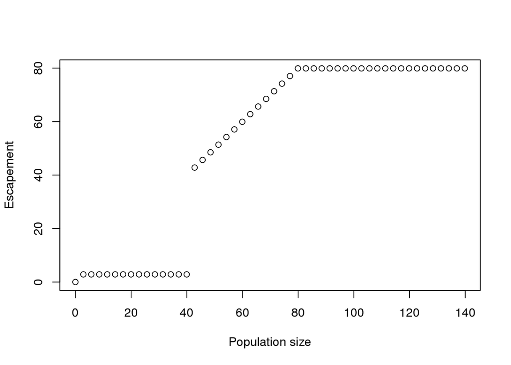

```r
plot(states, states - actions[mdp$policy],  xlab="Population size", ylab="Escapement")
```

Note that the altered award structure has almost no effect on the optimal policy given the true model, other than to avoid harvesting directly to zero even when the stock cannot persist, due to the explicit penalty for doing so.

```r
data.frame(reps = 1:50) %>%
  group_by(reps) %>%
  do(simulate_policy(states,actions, mdp$policy, f, z, s0 = 100, steps = 20, utility = pmin, discount = discount)[c("time", "state", "utility")]) ->
  sims

mean(sims$utility)
```

```
## [1] 9.796826
```

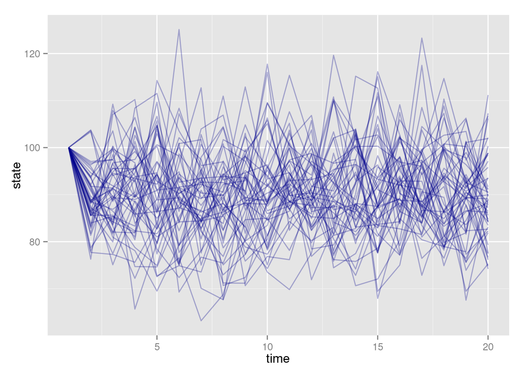

```r
ggplot(sims) + geom_line(aes(time, state, group = reps), alpha = 0.3, col = "darkblue")
```

30 Jul 2015

prev

[history](https://github.com/cboettig/2015/commits/master/_posts/2015-07-30-gpdp-via-mdptoolbox-cont.html)

Posted in

tags:

SHA Hash: